# JORN November 2024 Transects

Author

Alexi C. Besser

# READ ME

Preliminary analyses of modified LPI transect data collected at the Jornada Experiment Range 19-23 November 2024. 50 m transects: JORN002, JORN003, JORN005, JORN006, JORN007, JORN008, JORN009, JORN010, JORN011, JORN012, JORN014, JORN016, JORN018, JORN021, JORN022, JORN025, JORN027, JORN028, JORN030, JORN032, JORN034, JORN036, JORN038.

[figure not shown]

# Load Packages

```r
library(readr)
library(plyr)
library(dplyr)
library(stringr)
library(ggplot2)
library(ggpmisc)
```

# Read In and Clean Up Data

There are 23 csv files each containing data for one transect.

```r
# ### LEVEL 0 DATA ###
# # specify folder containing trasect data (individual csv files are considered Level 0 data)
# JORN_data_files <- dir("~/Downloads/JORN_Fall_2024_transect_data")
#
# # set working directory
# setwd("~/Downloads/JORN_Fall_2024_transect_data")
#
# ### LEVEL 1 DATA ###
# ### JORN_all_data ###
#
# # read in csv files and create a new column for transect id
# JORN_all_data <- read_csv(JORN_data_files, id = "Transect") %>%
#    mutate(Transect = str_remove_all(Transect, ".csv"))
#
# # write a csv file of the compiled (Level 1) data
# write.csv(JORN_all_data, "~/Desktop/JORN_LPI_L1_Fall_2024_Data.csv")
#
# # create a data frame for duplicate points
# JORN_duplicate_points <- JORN_all_data %>%
#   group_by(Transect, Remarks) %>%
#   filter(n() > 1) %>%
#   ungroup()
```

Investigate duplicate rows.

```r
# ### LEVEL 2 DATA ###
# ### JORN_trimmed_data ###
#
# # JORN010 (18): 3 rows with "75 m" for Remarks column ("33", "34", and "35" in ID column). All the attributes for two of these rows (IDs "34" and "35") are empty - these will be removed from the data frame.
# JORN_trimmed_data <- JORN_all_data[!(JORN_all_data$Transect=="JORN010" & JORN_all_data$ID == "34"),]
# JORN_trimmed_data <- JORN_trimmed_data[!(JORN_trimmed_data$Transect=="JORN010" & JORN_trimmed_data$ID == "35"),]
#
# # JORN021 (36): 2 rows with "36" for Remarks column ("15" and "16" in ID column). All the attributes for each row are identical - the second row (ID "16") will be removed from the data frame.
# JORN_trimmed_data <- JORN_trimmed_data[!(JORN_trimmed_data$Transect=="JORN021" & JORN_trimmed_data$ID == "16"),]
#
# # JORN022 (47): 2 rows with "47" for Remarks column ("4" and "5" in ID column). All the attributes for the second row (ID "5") are empty - this row will be removed from the data frame.
# JORN_trimmed_data <- JORN_trimmed_data[!(JORN_trimmed_data$Transect=="JORN022" & JORN_trimmed_data$ID == "5"),]
#
# # JORN028 (40): 2 rows with "40" for Remarks column ("11" and "12" in ID column). All the attributes for the second row (ID "12") are empty - this row will be removed from the data frame.
# JORN_trimmed_data <- JORN_trimmed_data[!(JORN_trimmed_data$Transect=="JORN028" & JORN_trimmed_data$ID == "12"),]
#
# # JORN028 (30): 2 rows with "30" for Remarks column ("22" and "23" in ID column). All the attributes for the second row (ID "23") are empty expect Litter_depth_south = 1 and Litter_depth_west = 4. The first row (ID "22") has Litter_depth_south = 1, but an NA for Litter_depth_west. Paste "4" into Litter_depth_west for ID "22" and delete ID "23" from the data frame.
# JORN_trimmed_data[JORN_trimmed_data$Transect=="JORN028" & JORN_trimmed_data$ID == "22", "Litter_depth_west"] <- 4
# JORN_trimmed_data <- JORN_trimmed_data[!(JORN_trimmed_data$Transect=="JORN028" & JORN_trimmed_data$ID == "23"),]
#
# # JORN032 (36): 2 rows with "36" for Remarks column ("15" and "16" in ID column). All the attributes for the second row (ID "16") are empty - this row will be removed from the data frame.
# JORN_trimmed_data <- JORN_trimmed_data[!(JORN_trimmed_data$Transect=="JORN032" & JORN_trimmed_data$ID == "16"),]
#
# # JORN032 (27): 2 rows with "27" for Remarks column ("25" and "26" in ID column). All the attributes for the second row (ID "26") are empty - this row will be removed from the data frame.
# JORN_trimmed_data <- JORN_trimmed_data[!(JORN_trimmed_data$Transect=="JORN032" & JORN_trimmed_data$ID == "26"),]
#
# # JORN032 (9): 2 rows with "9" for Remarks column ("44" and "45" in ID column). All the attributes for the second row (ID "45") are empty - this row will be removed from the data frame.
# JORN_trimmed_data <- JORN_trimmed_data[!(JORN_trimmed_data$Transect=="JORN032" & JORN_trimmed_data$ID == "45"),]
#
# # JORN034 (13): 2 rows with "13" for Remarks column ("39" and "40" in ID column). All the attributes for the second row (ID "40") are empty - this row will be removed from the data frame.
# JORN_trimmed_data <- JORN_trimmed_data[!(JORN_trimmed_data$Transect=="JORN034" & JORN_trimmed_data$ID == "40"),]
```

Look at unique Remarks.

```r
#
# Remarks <- unique(JORN_trimmed_data$Remarks)
# print(Remarks)
```

Investigate “NA” for Top_layer. And look at unique values for Top_layer_other to check for typos.

```r
# # create a data frame for rows with an "NA" for Top_layer
# NA_Top_layer_tab <- subset(JORN_trimmed_data, is.na(Top_layer))
#
# # there are 3 rows that have an "NA" for Top_layer
#
# # investigate Lower_1
# unique(NA_Top_layer_tab$Lower_1)
#
# # all Lower_1 values are either "N" or "NA"
#
# # let's go ahead and assume these rows should have an "N" for Top_layer
# JORN_trimmed_data$Top_layer[is.na(JORN_trimmed_data$Top_layer)] <- "N"
#
# # rename "N" to "None" for all rows
# JORN_trimmed_data$Top_layer[JORN_trimmed_data$Top_layer=="N"] <- "NONE"
#
# # look at unique values for Top_layer_other
# Top_layer_other <- unique(JORN_trimmed_data$Top_layer_other)
# print(Top_layer_other)
#
# # fix typos
#
# # "PGRL" appears once for transect JORN021 and once for transect JORN027 - this should be "PRGL"
# JORN_trimmed_data$Top_layer_other[JORN_trimmed_data$Top_layer_other=="PGRL"] <- "PRGL"
#
# # "RRGL" appears once for transect JORN030 - this should be "PRGL"
# JORN_trimmed_data$Top_layer_other[JORN_trimmed_data$Top_layer_other=="RRGL"] <- "PRGL"
#
# # "EPTI" appears three times for transect JORN014 - this should be "EPTO"
# JORN_trimmed_data$Top_layer_other[JORN_trimmed_data$Top_layer_other=="EPTI"] <- "EPTO"
#
# # "SOXX" appears once for transect JORN022 - change this to "SOEL"
# JORN_trimmed_data$Top_layer_other[JORN_trimmed_data$Top_layer_other=="SOXX"] <- "SOEL"
#
#
# # look at unique values for Top_layer_other
# Top_layer_other_cleaned <- unique(JORN_trimmed_data$Top_layer_other)
# print(Top_layer_other_cleaned)
#
# # rename "N" to "None" for all rows
# JORN_trimmed_data$Top_layer_other[is.na(JORN_trimmed_data$Top_layer_other)] <- "NONE"
```

Investigate “NA” for Soil_surface. And look at unique values for Soil_surface_other to check for typos.

```r
# # create a data frame for rows with an "NA" for Soil_surface
# NA_Soil_surface_tab <- subset(JORN_trimmed_data, is.na(Soil_surface))
#
# # there are 8 rows that have an "NA" for Soil_surface
#
# # Let's investigate Soil_surface_other before doing anything about the "NA" values
# unique(NA_Soil_surface_tab$Soil_surface_other)
#
# # default Soil_surface value was "SOIL" - let's go ahead and assume any "NA" values in this column should be "SOIL"
# # if Soil_surface is "NA" paste "SOIL"
# JORN_trimmed_data$Soil_surface[is.na(JORN_trimmed_data$Soil_surface)] <- "SOIL"
#
# # rename "CRST" to "CRUST"
# JORN_trimmed_data$Soil_surface[JORN_trimmed_data$Soil_surface=="CRST"] <- "CRUST"
#
# # look at unique values for Soil_surface_other
# Soil_surface_other <- unique(JORN_trimmed_data$Soil_surface_other)
# print(Soil_surface_other)
#
# # no typos
```

Investigate “NA” for Litter. And look at unique values for Litter_other to check for typos.

```r
# # create a data frame for rows with an "NA" for Litter
# NA_Litter_tab <- subset(JORN_trimmed_data, is.na(Litter))
#
# # there are 8 rows that have an "NA" for Litter
# # all of these rows also have "NA" in the Litter_other column - let's go ahead and assume any "NA" values in this column should be "N"
# # if Litter is "NA" paste "N"
# JORN_trimmed_data$Litter[is.na(JORN_trimmed_data$Litter)] <- "N"
#
# # rename "N" to "NONE"
# JORN_trimmed_data$Litter[JORN_trimmed_data$Litter=="N"] <- "NONE"
#
# # create a new data frame for rows that have "NONE" for Litter but still have a litter depth measurement
# litter_none_df <- JORN_trimmed_data %>%
#   filter(Litter == "NONE" & Litter_depth_center > 0 & Litter_depth_north > 0
#          & Litter_depth_east > 0 & Litter_depth_south > 0 & Litter_depth_west > 0)
# # there are none
#
# JORN_trimmed_data$Litter_depth_center[is.na(JORN_trimmed_data$Litter_depth_center)] <- 0
# JORN_trimmed_data$Litter_depth_north[is.na(JORN_trimmed_data$Litter_depth_north)] <- 0
# JORN_trimmed_data$Litter_depth_east[is.na(JORN_trimmed_data$Litter_depth_east)] <- 0
# JORN_trimmed_data$Litter_depth_south[is.na(JORN_trimmed_data$Litter_depth_south)] <- 0
# JORN_trimmed_data$Litter_depth_west[is.na(JORN_trimmed_data$Litter_depth_west)] <- 0
#
# # make sure Litter_depth values are numeric
# JORN_trimmed_data$Litter_depth_center <- as.numeric(JORN_trimmed_data$Litter_depth_center)
# JORN_trimmed_data$Litter_depth_north <- as.numeric(JORN_trimmed_data$Litter_depth_north)
# JORN_trimmed_data$Litter_depth_east <- as.numeric(JORN_trimmed_data$Litter_depth_east)
# JORN_trimmed_data$Litter_depth_south <- as.numeric(JORN_trimmed_data$Litter_depth_south)
# JORN_trimmed_data$Litter_depth_west <- as.numeric(JORN_trimmed_data$Litter_depth_west)
```

Investigate “NA” for Microsite.

```r
# # create a data frame for rows with an "NA" for Microsite
# NA_Microsite_tab <- subset(JORN_trimmed_data, is.na(Microsite))
#
# # there are 8 rows that have an "NA" for Microsite
# # let's investigate Microsite_other before doing anything about the "NA" values
# unique(NA_Microsite_tab$Microsite_other)
#
# # all of these rows also have "NA" in the Microsite_other column - let's go ahead and assume any "NA" values in this column should be "OPEN"
# # if Microsite is "NA" paste "OPEN"
# JORN_trimmed_data$Microsite[is.na(JORN_trimmed_data$Microsite)] <- "OPEN"
```

Investigate Top_height.

```r
# # if Top_height is "NA" paste "0"
# JORN_trimmed_data$Top_height[is.na(JORN_trimmed_data$Top_height)] <- 0
#
# # make sure Top_height values are numeric
# JORN_trimmed_data$Top_height <- as.numeric(JORN_trimmed_data$Top_height)
```

# Top Layer Plots

## Top Layer Frequencies Across Transects

### Top_layer Plot

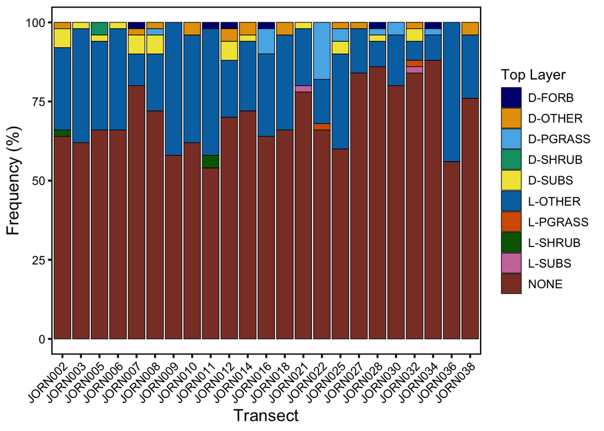

```r
JORN_trimmed_data <- read.csv("/Users/AlexiBesser/Desktop/JORN_LPI_L2_Fall_2024_Data.csv")

# first get counts, proportions, and percentages of each top layer type per transect
TopLayer <- JORN_trimmed_data %>%
  group_by(Top_layer, Transect) %>%
  dplyr::summarize(count = n(), .groups = "drop") %>%
  group_by(Transect) %>%
  dplyr::mutate(proportion = count / sum(count)) %>%
  dplyr::mutate(percent = proportion*100)

# make a bar plot
TopLayerPlot <- ggplot(TopLayer, aes(x = Transect, y = percent, fill = Top_layer)) +
  guides(fill = guide_legend(title.position = "top")) +
  labs(x = "Transect", y = "Frequency (%)", fill = "Top Layer") +
  geom_bar(stat = "identity", position = "stack", color = "black", linewidth = 0.25) +
  scale_fill_manual(values = c("navy", "#E69F00", "#56B4E9", "#009E73", "#F0E442",
                               "#0072B2", "#D55E00", "darkgreen", "#CC79A7", "coral4",
                               "#b66dff",  "cornsilk", "turquoise", "#999999",
                               "#000000")) +
  theme_bw() +
  theme(axis.text.x=element_text(angle=45,hjust=1)) +
  theme(
    axis.text.x = element_text(color="black", size=10),
    axis.text.y = element_text(color="black", size=10),
    legend.title = element_text(color="black", size=12),
    legend.text = element_text(color="black", size=10),
    legend.position = "right",
    axis.title.x = element_text(color="black", size=14),
    axis.title.y = element_text(color="black", size=14, angle=90),
    panel.grid.major = element_blank(), # switch off major grid lines
    panel.grid.minor = element_blank(), # switch off minor grid lines
    panel.border = element_rect(colour = "black", fill=NA, linewidth = 1),
    axis.ticks = element_line(color = "black", linewidth = 0.75))

TopLayerPlot
```

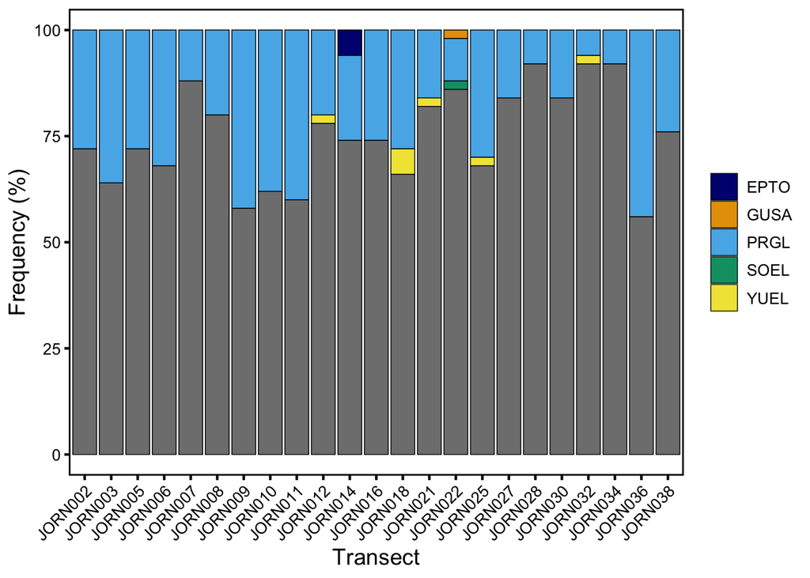

```r
# first, get counts, proportions, and percentages of each Top_layer_other category per transect
TopLayerOther <- JORN_trimmed_data %>%
  group_by(Top_layer_other, Transect) %>%
  dplyr::summarize(count = n(), .groups = "drop") %>%
  group_by(Transect) %>%
  dplyr::mutate(proportion = count / sum(count)) %>%
  dplyr::mutate(percent = proportion*100)

# make a bar plot
TopLayerOtherPlot <- ggplot(TopLayerOther, aes(x = Transect, y = percent, fill = Top_layer_other)) +
  guides(fill = guide_legend(title.position = "top")) +
  labs(x = "Transect", y = "Frequency (%)", fill = "Top Layer Other") +
  geom_bar(stat = "identity", position = "stack", color = "black", linewidth = 0.25) +
  scale_fill_manual(values = c("navy", "#E69F00", "#56B4E9", "#009E73", "#F0E442",
                               "#000000"),
                    name = NULL,
                    breaks = c("EPTO", "GUSA", "PRGL", "SOEL", "YUEL", "NONE"),
                    labels = c("EPTO", "GUSA", "PRGL", "SOEL", "YUEL", "NONE")) +
  theme_bw() +
  theme(axis.text.x=element_text(angle=45,hjust=1)) +
  theme(
    axis.text.x = element_text(color="black", size=10),
    axis.text.y = element_text(color="black", size=10),
    legend.title = element_text(color="black", size=12),
    legend.text = element_text(color="black", size=10),
    legend.position = "right",
    axis.title.x = element_text(color="black", size=14),
    axis.title.y = element_text(color="black", size=14, angle=90),
    panel.grid.major = element_blank(), # switch off major grid lines
    panel.grid.minor = element_blank(), # switch off minor grid lines
    panel.border = element_rect(colour = "black", fill=NA, linewidth = 1),
    axis.ticks = element_line(color = "black", linewidth = 0.75))

TopLayerOtherPlot
```

# Soil Surface Plots

## Soil Surface Frequencies Across Transects

### Soil_surface Plot

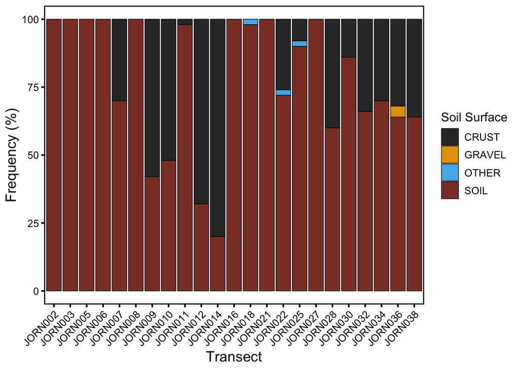

```r
# first, get counts, proportions, and percentages of each soil surface type per transect
SoilSurface <- JORN_trimmed_data %>%
  group_by(Soil_surface, Transect) %>%
  dplyr::summarize(count = n(), .groups = "drop") %>%
  group_by(Transect) %>%
  dplyr::mutate(proportion = count / sum(count)) %>%
  dplyr::mutate(percent = proportion*100)

# make a bar plot
SoilSurfacePlot <- ggplot(SoilSurface, aes(x = Transect, y = percent, fill = Soil_surface)) +
  guides(fill = guide_legend(title.position = "top")) +
  labs(x = "Transect", y = "Frequency (%)", fill = "Soil Surface") +
  geom_bar(stat = "identity", position = "stack", color = "black", linewidth = 0.25) +
  scale_fill_manual(values = c("gray20", "#E69F00", "#56B4E9", "coral4", "#D55E00",
                               "burlywood", "#999999", "burlywood4",
                               "darkslateblue")) +
  theme_bw() +
  theme(axis.text.x=element_text(angle=45,hjust=1)) +
  theme(
    axis.text.x = element_text(color="black", size=10),
    axis.text.y = element_text(color="black", size=10),
    legend.title = element_text(color="black", size=12),
    legend.text = element_text(color="black", size=10),
    legend.position = "right",
    axis.title.x = element_text(color="black", size=14),
    axis.title.y = element_text(color="black", size=14, angle=90),
    panel.grid.major = element_blank(), # switch off major grid lines
    panel.grid.minor = element_blank(), # switch off minor grid lines
    panel.border = element_rect(colour = "black", fill=NA, linewidth = 1),
    axis.ticks = element_line(color = "black", linewidth = 0.75))

SoilSurfacePlot
```

## Top Layer Frequencies Across Soil Surfaces

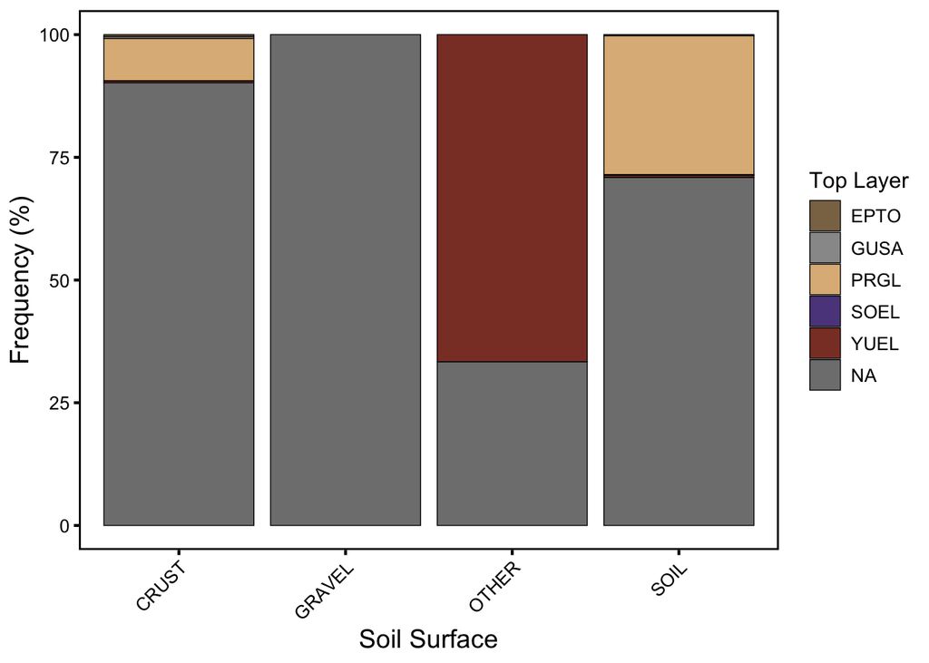

```r
# first, get counts, proportions, and percentages of each top layer type per transect
SoilTopLayer <- JORN_trimmed_data %>%
  group_by(Top_layer_other, Soil_surface) %>%
  dplyr::summarize(count = n(), .groups = "drop") %>%
  group_by(Soil_surface) %>%
  dplyr::mutate(proportion = count / sum(count)) %>%
  dplyr::mutate(percent = proportion*100)

# make a bar plot
SoilTopLayerPlot <- ggplot(SoilTopLayer, aes(x = Soil_surface, y = percent, fill = Top_layer_other)) +
  guides(fill = guide_legend(title.position = "top")) +
  labs(x = "Soil Surface", y = "Frequency (%)", fill = "Top Layer") +
  geom_bar(stat = "identity", position = "stack", color = "black", linewidth = 0.25) +
  scale_fill_manual(values = c("burlywood4", "#999999", "burlywood", "mediumpurple4",
                               "coral4", "#D55E00", "#E69F00", "#F0E442", "#009E73",
                               "#CC79A7", "#0072B2", "cornsilk2", "darkgreen",
                               "olivedrab3", "#000000")) +
  theme_bw() +
  theme(axis.text.x=element_text(angle=45,hjust=1)) +
  theme(
    axis.text.x = element_text(color="black", size=10),
    axis.text.y = element_text(color="black", size=10),
    legend.title = element_text(color="black", size=12),
    legend.text = element_text(color="black", size=10),
    legend.position = "right",
    axis.title.x = element_text(color="black", size=14),
    axis.title.y = element_text(color="black", size=14, angle=90),
    panel.grid.major = element_blank(), # switch off major grid lines
    panel.grid.minor = element_blank(), # switch off minor grid lines
    panel.border = element_rect(colour = "black", fill=NA, linewidth = 1),
    axis.ticks = element_line(color = "black", linewidth = 0.75))

SoilTopLayerPlot
```

# Litter Plots

## Litter Types and Depths Across Transects

### Litter Plot

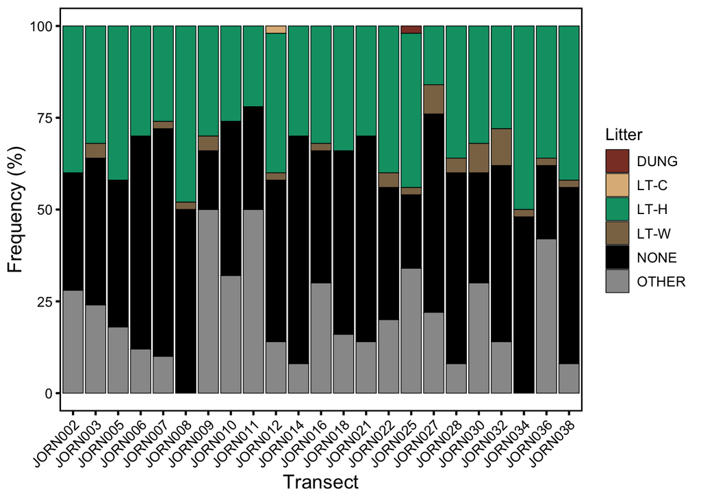

```r
# first, get counts, proportions, and percentages of each litter type per transect
LitterTransect <- JORN_trimmed_data %>%
  group_by(Litter, Transect) %>%
  dplyr::summarize(totdepth_center = sum(Litter_depth_center),
                   totdepth_north = sum(Litter_depth_north),
                   totdepth_east = sum(Litter_depth_east),
                   totdepth_south = sum(Litter_depth_south),
                   totdepth_west = sum(Litter_depth_west),
                   n = n(), .groups = "drop") %>%
  group_by(Transect) %>%
  dplyr::mutate(proportion = n / sum(n)) %>%
  dplyr::mutate(percent = proportion*100)

# make a bar plot
LitterPlot <- ggplot(LitterTransect, aes(x = Transect, y = percent, fill = Litter)) +
  guides(fill = guide_legend(title.position = "top")) +
  labs(x = "Transect", y = "Frequency (%)", fill = "Litter") +
  geom_bar(stat = "identity", position = "stack", color = "black", linewidth = 0.25) +
  scale_fill_manual(values = c("coral4", "burlywood", "#009E73", "burlywood4",
                               "black", "#999999")) +
  theme_bw() +
  theme(axis.text.x=element_text(angle=45,hjust=1)) +
  theme(
    axis.text.x = element_text(color="black", size=10),
    axis.text.y = element_text(color="black", size=10),
    legend.title = element_text(color="black", size=12),
    legend.text = element_text(color="black", size=10),
    legend.position = "right",
    axis.title.x = element_text(color="black", size=14),
    axis.title.y = element_text(color="black", size=14, angle=90),
    panel.grid.major = element_blank(), # switch off major grid lines
    panel.grid.minor = element_blank(), # switch off minor grid lines
    panel.border = element_rect(colour = "black", fill=NA, linewidth = 1),
    axis.ticks = element_line(color = "black", linewidth = 0.75))

LitterPlot
```

### Litter_depth Plot

Make plot that shows litter type and cumulative depth across transects.

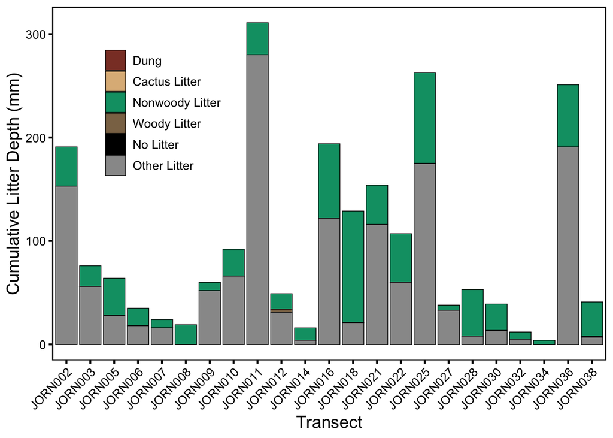

```r
# make a bar plot
LitterDepthPlot <- ggplot(LitterTransect, aes(x = Transect, y = totdepth_center,
                                           fill = Litter)) +
  guides(fill = guide_legend(title.position = "top")) +
  labs(x = "Transect", y = "Cumulative Litter Depth (mm)", fill = "Litter Type") +
  geom_bar(stat = "identity", position = "stack", color = "black", linewidth = 0.25) +
  scale_fill_manual(values = c("coral4", "burlywood", "#009E73", "burlywood4",
                               "black", "#999999"),
                    name = NULL,
                    breaks = c("DUNG", "LT-C", "LT-H", "LT-W", "NONE",
                               "OTHER"),
                    labels = c("Dung", "Cactus Litter", "Nonwoody Litter",
                               "Woody Litter", "No Litter", "Other Litter")) +
  theme_bw() +
  theme(axis.text.x=element_text(angle=45,hjust=1)) +
  theme(
    axis.text.x = element_text(color="black", size=10),
    axis.text.y = element_text(color="black", size=10),
    legend.title = element_text(color="black", size=12),
    legend.text = element_text(color="black", size=10),
    legend.position = c(.2,.7),
    axis.title.x = element_text(color="black", size=14),
    axis.title.y = element_text(color="black", size=14, angle=90),
    panel.grid.major = element_blank(), # switch off major grid lines
    panel.grid.minor = element_blank(), # switch off minor grid lines
    panel.border = element_rect(colour = "black", fill=NA, linewidth = 1),
    axis.ticks = element_line(color = "black", linewidth = 0.75))
LitterDepthPlot
```

## Litter Types and Depths Across Soil Surfaces

Make a plot of litter type and cumulative depth as a function of soil surface.

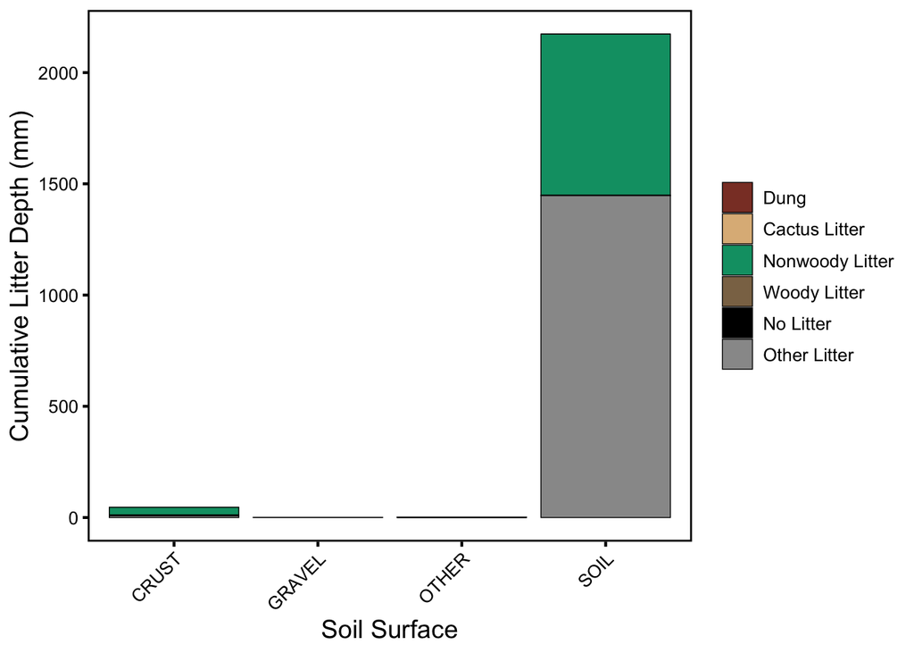

```r
# first, get total depths of each litter type per soil surface type
LitterSoil <- JORN_trimmed_data %>%
  group_by(Soil_surface, Litter) %>%
  dplyr::summarize(totdepth_center = sum(Litter_depth_center),
                   totdepth_north = sum(Litter_depth_north),
                   totdepth_east = sum(Litter_depth_east),
                   totdepth_south = sum(Litter_depth_south),
                   totdepth_west = sum(Litter_depth_west),
                   n = n(), .groups = "drop")

# make a bar plot
LitterSoilPlot <- ggplot(LitterSoil, aes(x = Soil_surface, y = totdepth_center,
                                         fill = Litter)) +
  guides(fill = guide_legend(title.position = "top")) +
  labs(x = "Soil Surface", y = "Cumulative Litter Depth (mm)", fill = "Litter Type") +
  geom_bar(stat = "identity", position = "stack", color = "black", linewidth = 0.25) +
  scale_fill_manual(values = c("coral4", "burlywood", "#009E73", "burlywood4",
                               "black", "#999999"),
                    name = NULL,
                    breaks = c("DUNG", "LT-C", "LT-H", "LT-W", "NONE",
                               "OTHER"),
                    labels = c("Dung", "Cactus Litter", "Nonwoody Litter",
                               "Woody Litter", "No Litter", "Other Litter")) +
  theme_bw() +
  theme(axis.text.x=element_text(angle=45,hjust=1)) +
  theme(
    axis.text.x = element_text(color="black", size=10),
    axis.text.y = element_text(color="black", size=10),
    legend.title = element_text(color="black", size=12),
    legend.text = element_text(color="black", size=10),
    legend.position = "right",
    axis.title.x = element_text(color="black", size=14),
    axis.title.y = element_text(color="black", size=14, angle=90),
    panel.grid.major = element_blank(), # switch off major grid lines
    panel.grid.minor = element_blank(), # switch off minor grid lines
    panel.border = element_rect(colour = "black", fill=NA, linewidth = 1),
    axis.ticks = element_line(color = "black", linewidth = 0.75))

LitterSoilPlot
```

## Litter Types and Depths Across Microsites

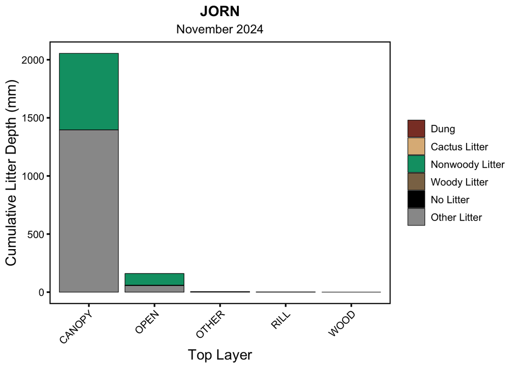

```r
# first, get counts, proportions, and percentages of each litter type per top layer category
LitterTop <- JORN_trimmed_data %>%
  group_by(Litter, Microsite) %>%
  dplyr::summarize(totdepth_center = sum(Litter_depth_center),
                   totdepth_north = sum(Litter_depth_north),
                   totdepth_east = sum(Litter_depth_east),
                   totdepth_south = sum(Litter_depth_south),
                   totdepth_west = sum(Litter_depth_west),
                   n = n(), .groups = "drop")

# make a bar plot
LitterTopPlot <- ggplot(LitterTop, aes(x = Microsite, y = totdepth_center,
                                       fill = Litter)) +
  guides(fill = guide_legend(title.position = "top")) +
  labs(x = "Top Layer", y = "Cumulative Litter Depth (mm)", fill = "Litter Type") +
  geom_bar(stat = "identity", position = "stack", color = "black", linewidth = 0.25) +
  scale_fill_manual(values = c("coral4", "burlywood", "#009E73", "burlywood4",
                               "black", "#999999"),
                    name = NULL,
                    breaks = c("DUNG", "LT-C", "LT-H", "LT-W", "NONE",
                               "OTHER"),
                    labels = c("Dung", "Cactus Litter", "Nonwoody Litter",
                               "Woody Litter", "No Litter", "Other Litter")) +
  theme_bw() +
  theme(axis.text.x=element_text(angle=45,hjust=1)) +
  theme(
    axis.text.x = element_text(color="black", size=10),
    axis.text.y = element_text(color="black", size=10),
    legend.title = element_text(color="black", size=12),
    legend.text = element_text(color="black", size=10),
    legend.position = "right",
    axis.title.x = element_text(color="black", size=14),
    axis.title.y = element_text(color="black", size=14, angle=90),
    panel.grid.major = element_blank(), # switch off major grid lines
    panel.grid.minor = element_blank(), # switch off minor grid lines
    panel.border = element_rect(colour = "black", fill=NA, linewidth = 1),
    axis.ticks = element_line(color = "black", linewidth = 0.75)) +
  ggtitle(label = "JORN", subtitle = "November 2024") +
  theme(plot.title = element_text(size = 14, face = "bold", hjust = 0.5),
        plot.subtitle = element_text(size = 12, hjust = 0.5))

LitterTopPlot
```

```r
# A LOT of the "OTHER" litter type is actually just a combination of litter types
# need to work on some code to categorize the "OTHER" litter types better
```

```r
# look at unique values for Litter_other
Litter_other <- unique(JORN_trimmed_data$Litter_other)
print(Litter_other)
```

```
 [1] NA           "H_W"        "H_W_B"      "H_B"        "B"
 [6] "W_B"        "YUEL"       "SEED"       "H_YUEL"     "W_YUEL"
[11] "H_W_B_DUNG" "H_W_DUNG"
```

```r
# Make a new column
JORN_trimmed_data$Litter_Plotting <- JORN_trimmed_data$Litter

# if Litter_other is "H_W" paste "Nonwoody and Woody Litter"
for (i in 1:nrow(JORN_trimmed_data)) {
  if (!is.na(JORN_trimmed_data$Litter_other[i]) &&
      JORN_trimmed_data$Litter_other[i] == "H_W")
    {JORN_trimmed_data$Litter_Plotting[i] <- "Nonwoody and Woody Litter"}
}

# if Litter_other is "H_W_B" paste "Nonwoody and Woody Litter"
for (i in 1:nrow(JORN_trimmed_data)) {
  if (!is.na(JORN_trimmed_data$Litter_other[i]) &&
      JORN_trimmed_data$Litter_other[i] == "H_W_B")
    {JORN_trimmed_data$Litter_Plotting[i] <- "Nonwoody and Woody Litter"}
}

# if Litter_other is "H_B" paste "Nonwoody and Woody Litter"
for (i in 1:nrow(JORN_trimmed_data)) {
  if (!is.na(JORN_trimmed_data$Litter_other[i]) &&
      JORN_trimmed_data$Litter_other[i] == "H_W")
    {JORN_trimmed_data$Litter_Plotting[i] <- "Nonwoody and Woody Litter"}
}
```

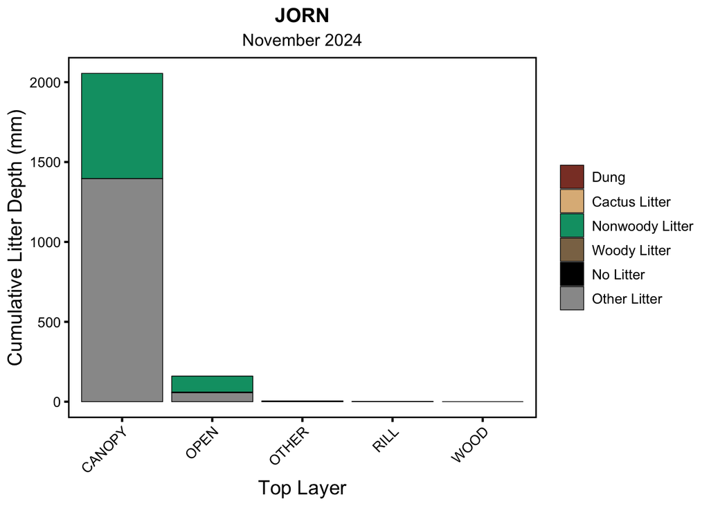

```r
# first, get counts, proportions, and percentages of each litter type per top layer category
LitterMic <- JORN_trimmed_data %>%
  group_by(Litter_Plotting, Microsite) %>%
  dplyr::summarize(totdepth_center = sum(Litter_depth_center),
                   totdepth_north = sum(Litter_depth_north),
                   totdepth_east = sum(Litter_depth_east),
                   totdepth_south = sum(Litter_depth_south),
                   totdepth_west = sum(Litter_depth_west),
                   n = n(),
                   mean_totdepth_all = (sum(Litter_depth_center) +
                     sum(Litter_depth_north) + sum(Litter_depth_east) +
                     sum(Litter_depth_south) + sum(Litter_depth_west))/(5*n),
                   .groups = "drop")

# next, calculate the total number of observations per microsite
MicroFreq <- JORN_trimmed_data %>%
  group_by(Microsite) %>%
  dplyr::summarize(nMic = n(), .groups = "drop")

# merge the MicroFreq data frame with the LitterStatsMicro data frame
LitterMic <- LitterMic %>%
  left_join(MicroFreq, by = c("Microsite"))

# calculate the total number of observations
total_mic_counts <- sum(LitterMic$n)

# calculate the maximum sum of mean litter depths for a top layer category
sum_mean_depth_max_mic <- LitterMic %>%
  group_by(Microsite) %>%
  summarize(sum_mean_depth = sum(mean_totdepth_all)) %>%
  summarize(sum_mean_depth_max = max(sum_mean_depth)) %>%
  pull(sum_mean_depth_max)

# calculate the maximum total number of observations per microsite
mic_freq_max <- max(LitterMic$nMic)

# make a bar plot
LitterMicPlot <- ggplot(LitterMic, aes(x = Microsite, y = totdepth_center,
                                       fill = Litter_Plotting)) +
  guides(fill = guide_legend(title.position = "top")) +
  labs(x = "Microsite", y = "Cumulative Litter Depth (mm)", fill = "Litter Type") +
  geom_bar(stat = "identity", position = "stack", color = "black", linewidth = 0.25) +
  scale_fill_manual(values = c("burlywood", "#009E73", "#006B4E", "burlywood4",
                               "saddlebrown", "#999999", "black", "navy"),
                    name = NULL,
                    breaks = c("LT-C", "LT-H", "Nonwoody and Woody Litter",
                               "LT-W", "DUNG", "OTHER", "NONE", "n"),
                    labels = c("Cactus Litter", "Nonwoody Litter",
                               "Nonwoody and Woody Litter", "Woody Litter",
                               "Dung", "Other Litter", "No Litter", "Count")) +
  theme_bw() +
  theme(axis.text.x=element_text(angle=45,hjust=1)) +
  theme(
    axis.text.x = element_text(color="black", size=10),
    axis.text.y = element_text(color="black", size=10),
    legend.title = element_text(color="black", size=12),
    legend.text = element_text(color="black", size=10),
    legend.position = "right",
    axis.title.x = element_text(color="black", size=14),
    axis.title.y = element_text(color="black", size=14, angle=90),
    panel.grid.major = element_blank(), # switch off major grid lines
    panel.grid.minor = element_blank(), # switch off minor grid lines
    panel.border = element_rect(colour = "black", fill=NA, linewidth = 1),
    axis.ticks = element_line(color = "black", linewidth = 0.75)) +
  ggtitle(label = "JORN", subtitle = "November 2024") +
  theme(plot.title = element_text(size = 14, face = "bold", hjust = 0.5),
        plot.subtitle = element_text(size = 12, hjust = 0.5))

LitterTopPlot
```

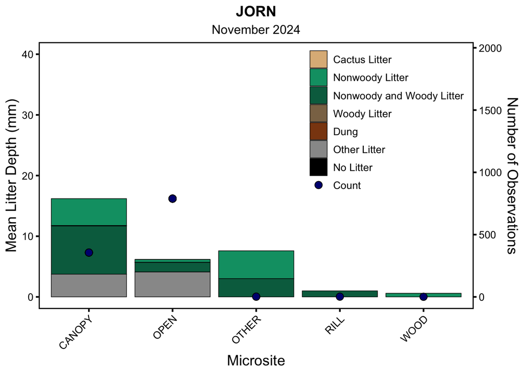

```r
ggsave("~/Desktop/JORN_Microsite_Cumulative_litter.pdf", LitterTopPlot, width = 10,
       height = 6)



LitterMicPlot <- ggplot(LitterMic, aes(x = Microsite, y = mean_totdepth_all,
                                       fill = Litter_Plotting)) +
  guides(fill = guide_legend(title.position = "top")) +
  labs(x = "Microsite", y = "Mean Litter Depth (mm)", fill = "Litter Type") +
  geom_bar(stat = "identity", position = "stack", color = "black", linewidth = 0.25) +
  geom_point(aes(y = nMic*(sum_mean_depth_max_mic/mic_freq_max), fill = "n"),
             size = 3, pch = 21, color = "black") +
  scale_fill_manual(values = c("burlywood", "#009E73", "#006B4E", "burlywood4",
                               "saddlebrown", "#999999", "black", "navy"),
                    name = NULL,
                    breaks = c("LT-C", "LT-H", "Nonwoody and Woody Litter",
                               "LT-W", "DUNG", "OTHER", "NONE", "n"),
                    labels = c("Cactus Litter", "Nonwoody Litter",
                               "Nonwoody and Woody Litter", "Woody Litter",
                               "Dung", "Other Litter", "No Litter", "Count")) +
  scale_y_continuous(
    name = "Mean Litter Depth (mm)",
    limits = c(0, 40),
    sec.axis = sec_axis(~ . * (mic_freq_max/sum_mean_depth_max_mic),
                        name = "Number of Observations")) +
  theme_bw() +
  theme(axis.text.x=element_text(angle=45,hjust=1)) +
  theme(
    axis.text.x = element_text(color="black", size=10),
    axis.text.y = element_text(color="black", size=10),
    legend.title = element_text(color="black", size=12),
    legend.text = element_text(color="black", size=10),
    legend.position = (c(0.8, 0.7)),
    axis.title.x = element_text(color="black", size=14),
    axis.title.y = element_text(color="black", size=14, angle=90),
    panel.grid.major = element_blank(), # switch off major grid lines
    panel.grid.minor = element_blank(), # switch off minor grid lines
    panel.border = element_rect(colour = "black", fill=NA, linewidth = 1),
    axis.ticks = element_line(color = "black", linewidth = 0.75)) +
  ggtitle(label = "JORN", subtitle = "November 2024") +
  theme(plot.title = element_text(size = 14, face = "bold", hjust = 0.5),
        plot.subtitle = element_text(size = 12, hjust = 0.5))

LitterMicPlot
```

```r
ggsave("~/Desktop/JORN_Microsite_Mean_Litter.pdf", LitterMicPlot, width = 10,
       height = 6)
```

```r
LitterTransect_all <- JORN_trimmed_data %>%
  group_by(Transect) %>%
  dplyr::summarize(totdepth = sum(Litter_depth_center), n = n(),
                   elev = mean(Elevation), .groups = "drop")

elev_lm <- lm(totdepth ~ elev, data = LitterTransect_all)
summary(elev_lm)
```

```
Call:
lm(formula = totdepth ~ elev, data = LitterTransect_all)

Residuals:
   Min     1Q Median     3Q    Max
-98.74 -61.90 -38.79  42.53 212.31

Coefficients:
             Estimate Std. Error t value Pr(>|t|)
(Intercept) -2460.993   5228.043  -0.471    0.643
elev            1.967      4.020   0.489    0.630

Residual standard error: 90.65 on 21 degrees of freedom
Multiple R-squared:  0.01127,   Adjusted R-squared:  -0.03581
F-statistic: 0.2393 on 1 and 21 DF,  p-value: 0.6298
```

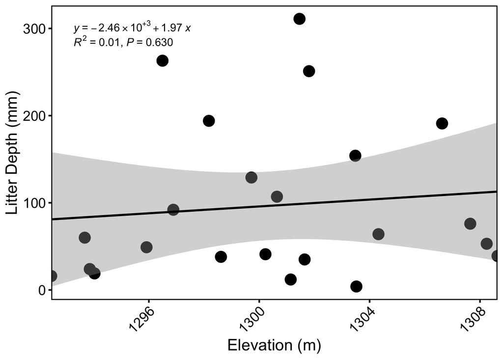

```r
elev_depth <- ggplot(LitterTransect_all, aes(x = elev, y = totdepth)) +
  geom_point(pch = 19, size = 5) +
  stat_smooth(method = "lm", formula = y ~ x, fullrange = TRUE, color = "black") +
  stat_poly_eq(use_label("eq"), formula = y ~ x) +
  stat_poly_eq(use_label("R2", "P"), formula = y ~ x, label.y = 0.9) +
  scale_x_continuous(expand = c(0, 0)) +
  labs(x = "Elevation (m)", y = "Litter Depth (mm)", fill = "Litter Type") +
  theme_bw() +
  theme(axis.text.x=element_text(angle=45,hjust=1)) +
  theme(
    axis.text.x = element_text(color="black", size=14),
    axis.text.y = element_text(color="black", size=14),
    legend.title = element_text(color="black", size=14),
    legend.text = element_text(color="black", size=14),
    legend.position = "right",
    axis.title.x = element_text(color="black", size=16),
    axis.title.y = element_text(color="black", size=16, angle=90),
    panel.grid.major = element_blank(), # switch off major grid lines
    panel.grid.minor = element_blank(), # switch off minor grid lines
    panel.border = element_rect(colour = "black", fill=NA, linewidth = 1),
    axis.ticks = element_line(color = "black", linewidth = 0.75))

elev_depth
```